# Lesson 2 Lecture Info

ANTH 102-W1

### What to expect

Activities for this lesson include participation in a discussion forum and a quiz. To prepare you for these activities, this lesson includes a slideshow and various online resources (websites, video, etc.). You should take advantage of all of these resources.

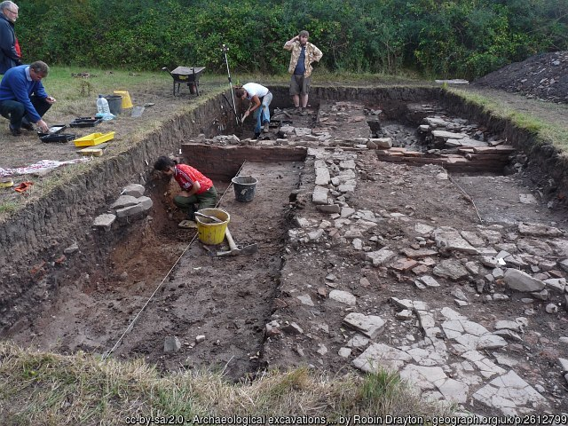

This shows the quayside of [the newly discovered Roman port](http://www.geograph.org.uk/reuse.php?id=2612799) on the River Usk; the first to be located outside London. The river runs just beyond the hedge in the background.

### A note on linked web resources

Remember, take the time to check out the web links I provide. They can clarify highlights that you find in the lecture slideshow. Before getting started, check to see if you have fallen prey to any [common misconceptions about archaeology](http://www.saa.org/AbouttheSociety/EducationandOutreach/CurriculumLinks/ArchaeologyintheClassroom/MythsandMisconceptions/tabid/209/Default.aspx), some of which have already been considered.

If a hyperlink doesn’t work with a simple click, right-click and select “Open in a new tab/window.”

[video not shown]

### Lecture Slideshow

To provide more background information and highlight the main concepts, I have provided a slideshow on the following page.

### Readings

We are concentrating on the “how to” of archaeology in this lesson, including why archaeologists use specific methods. For example: [Why do archaeologists dig square holes?](http://www.southalabama.edu/archaeology/education_why-archaeologists-dig-square-holes.html)

### What’s next?

- Lesson 2 Discussion: How to “Archaeologize”
- Lesson 2 Quiz: This quiz will review some of the pertinent points from this lesson. If needed, you may use any provided content to answer the questions.

#### Continue

Continue through the module to access the slideshow and other content.